# Structural Topic models

### Introduction

This document is a a demo on how to run Structural Topic Models in R. Readers can read more at: http://www.structuraltopicmodel.com/

```r
data_all <- read.delim2("../data/texts/echr.200.tsv",
            encoding = "UTF-8")
```

```
EOF within quoted string
```

```r
processed <- textProcessor(documents = data_all$TEXT,
                      metadata = data_all[c("PERIOD", "CASENO")],
                      stem = FALSE,
                      customstopwords = c("ECHR", "article", "judgment", "strasbourg", "section", "chamber", "eur"))
```

```
Building corpus...
Converting to Lower Case...
Removing stopwords...
Remove Custom Stopwords...
Removing numbers...
Removing punctuation...
Creating Output...
```

Final preparation step to remove infrequent words

```r
out <- prepDocuments(processed$documents,
                     vocab = processed$vocab,
                     meta = processed$meta,
                     lower.thresh = 5) # remove words appearing in less than 5 documents
```

```
Removing 18449 of 23545 terms (29572 of 195084 tokens) due to frequency
Your corpus now has 200 documents, 5096 terms and 165512 tokens.
```

We will now select the best value for the number of topics $k$. The method `searchK` does exacly this. We will try to see if the topics have some dependency on the period, therefore we will add the argument `prevalence =~ PERIOD`

```r
storage <- searchK(out$documents,
                   out$vocab,
                   K = c(10,20,30,50),
                   prevalence =~ PERIOD,
                   data = out$meta)
```

We will now plot the results. We can see from the plot that K = 20 gives the best results

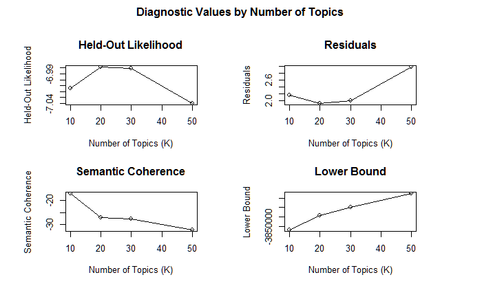

Thus we will run the model for *K=20*. Note that we supply a *seed* to ensure replication of results because otherwise the exact topic allocation will vary

```r
model <- stm(out$documents,
             out$vocab,
             K = 20,
             prevalence =~ PERIOD,
             max.em.its = 75,
             data = out$meta, init.type = "Spectral",
             seed = 1) # the seed is needed to ensure replication of results
```

```
Beginning Initialization.
     Calculating the gram matrix...
     Finding anchor words...
    ....................
     Recovering initialization...
    .......................
```

We will plot a summary of our models to be able to see what each models is about

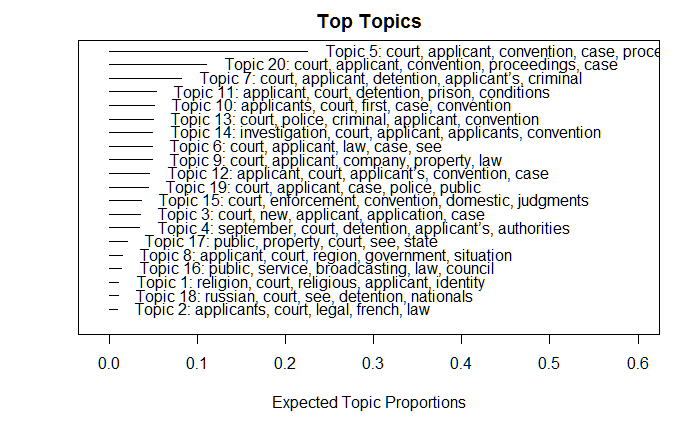

```r
plot(model, type = "summary", xlim = c(-0.01, 0.6), n = 5)
```

Lets now see which documents are about Topic 11 which seems to be about *prison conditions and inhuman treatment*. We will isolate the beginning of each judment in a variable called `shortdoc`. This will be used to identify the top judgments for the Topic. `findThoughts` finds the top-n documents per topic and here we select `n=2`

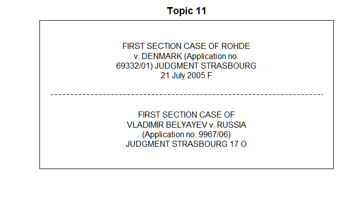

```r
shortdoc <- lapply(data_all$TEXT, function(x) substr(x,1,100))
thoughts11 <- findThoughts(model, shortdoc, n=2, topics = 11)$docs[[1]]
plotQuote(thoughts11, width = 30, main = "Topic 11")
```

We can see that the first case is *Rohde v. Denmark* http://hudoc.echr.coe.int/eng?i=001-69794, indeed about *pre-trial detention* and inuman treatment

We will next see if Topics 11, 14 and 1 depend on the period

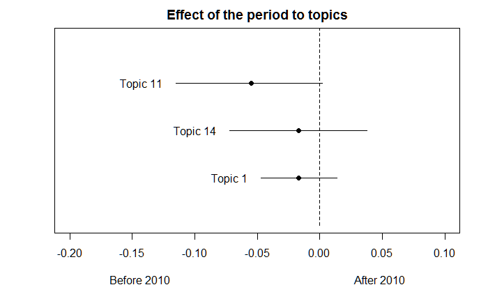

```r
prep <- estimateEffect(1:20 ~ PERIOD,
                       model,
                       metadata = out$meta,
                       uncertainty = "Global")
plot.estimateEffect(prep, covariate = "PERIOD", topics = c(11, 14, 1),
                    model = model,
                    cov.value1 = "BEFORE2010",
                    cov.value2 = "AFTER2010",
                    method = "difference",
                    main = "Effect of the period to topics",
                    labeltype = "custom",
                    custom.labels = c("Topic 11", "Topic 14", "Topic 1"),
                     xlim = c(-0.2, 0.1),
                    xlab = "Before 2010                                                                  After 2010")
```

```r
NA
```